# Deutsch-Josza Algorithm

```python
import warnings
warnings.filterwarnings('ignore')
```

```python
from matplotlib import pyplot as plt
import numpy as np

from qiskit import IBMQ, QuantumCircuit, Aer, QuantumRegister, ClassicalRegister, execute
from qiskit.visualization import plot_bloch_multivector, plot_histogram, plot_bloch_vector
import qiskit.tools.jupyter
from qiskit.quantum_info import Statevector
```

Tomemos o problema de Deutsch-Josza com $n=8$ (ou seja, um byte de informação). Temos de começar por definir o oráculo e o $U_f$. Também queremos uma função abstrata $f(x)$ que podemos escolher ser equilibrada (metade dos outputs são 0 e metade são 1) ou constante (todos os outputs são iguais).

```python
# variável bool para decidirmos se é constante ou equilibrado, para testar
constante = False
```

```python
def sim_and_count(circuito, backend_usado='qasm_simulator'):
    """Correr um circuito num backend ou simulador e contar os resultados obtidos"""
    backend = Aer.get_backend(backend_usado)  # para correr num computador quântico, basta trocar para um backend a sério
    results = execute(circuito, backend=backend, shots=100).result()
    counts = results.get_counts()
    return counts
```

Problema: como o $f(x)$ é abstrato, o oráculo também o será. Ou seja, se eu quero implementar em python, só posso fazer um oráculo se eu souber o $f(x)$; caso contrário, não posso fazer nada. Ou seja. o algorítmo de Deutsch-Josza não é... muito prático. Don't get me wrong, thinking about oracle is useful, mas tal como diz no site do qiskit: "in standard computational methods, inputs are strings of bits, NOT oracles". Still, tentemos aplicar Deutsch-Josza, tendo então o oráculo como o nosso input da função...

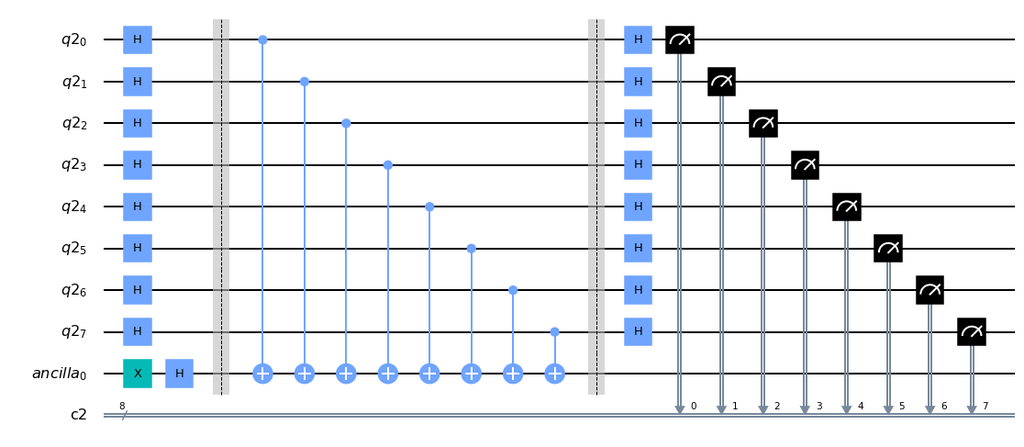

```python
q_reg=QuantumRegister(8)  # os nossos 8 qubits
q_ancilla=QuantumRegister(1, name="ancilla")  # qubit adicional, para servir do y nas nossas contas do oráculo
c_reg=ClassicalRegister(8)
qc = QuantumCircuit(q_reg, q_ancilla, c_reg)

# COMEÇAR A CONSTRUIR O CIRCUITO ELÉTRICO
qc.x(8)
qc.h([0,1,2,3,4,5,6,7,8])  # hadamard gate, equivalente ao gate U2(0,pi)
qc.barrier()

if constante:
    pass  # não faremos nada, o que é uma das opções que podemos ter, quando ele é constante
    # também podiamos ter aplicado o X-gate a todos (dar flip a todos), mas não fazer nada também funciona
else:
    # para o caso equilibrado, adicionaremos C-NOT gates (justificação abaixo)
    for i in range(8):
        qc.cx(i, 8)

qc.barrier()
qc.h([0,1,2,3,4,5,6,7])
for i in range(8):
    qc.measure(i, c_reg[i])
qc.draw(output='mpl')  # colocar output='mpl' coloca este estilo visual mais agradável
```

Porque adicionar C-NOT gates, no caso equilibrado? O nosso objetivo é aplicar $U_f |x \rangle = (-1)^{f(x)}|x \rangle$; ou seja, a metade deles, queremos rodar o qubit. Com o C-NOT gate, é isso que estaremos a fazer a metade deles, tendo a ancilla como controlo. Agora, se tu executares o código e olhares para os C-NOT gates, vais ver algo que parece errado. Eles não deviam estar ao contrário? Não.

Passa-se que, quando temos um C-NOT, sendo o qubit `q0` o controlo e o qubit `q1` o que queremos atuar, se eles estiverem no meio de hadamard gates, é o mesmo que ter apenas um C-NOT gate onde `q1` é o controlo e `q0` onde estamos a atuar. Prova exemplo, com nomenclatura matemática aldrabada (usando o operador $\hat{C}$ para simbolizar o C-NOT gate):

$\hat{H} \hat{C} \hat{H} |01\rangle = \hat{H} \hat{C} \hat{H} \begin{bmatrix}1\\0\end{bmatrix}\begin{bmatrix}0\\1\end{bmatrix} = \displaystyle{\frac{1}{\sqrt{2}}} \hat{H} \hat{C} \begin{bmatrix}1\\1\end{bmatrix}\begin{bmatrix}1\\-1\end{bmatrix} = \displaystyle{\frac{1}{\sqrt{2}}} \hat{H} \hat{C} \begin{bmatrix}1\\-1\\1\\-1\end{bmatrix} = \displaystyle{\frac{1}{\sqrt{2}}} \hat{H} \begin{bmatrix}1\\-1\\-1\\1\end{bmatrix} = \displaystyle{\frac{1}{\sqrt{2}}} \hat{H} \begin{bmatrix}1\\-1\end{bmatrix}\begin{bmatrix}1\\-1\end{bmatrix} = \displaystyle{\frac{1}{2}} \begin{bmatrix}0\\2\end{bmatrix}\begin{bmatrix}0\\2\end{bmatrix} = |11\rangle.$

Mas agora a verdadeira pergunta: "Porque raio é que, ao encher aquilo de C-NOT gates, corresponde a equilibrado? como o termo ancillar é 1, não estará a transformar tudo em 1?". Sim, transformará tudo em 1. No entanto, estás a olhar para isto do ponto de vista TOTAL! No TOTAL, sim, transformará tudo em 1. Mas só dentro do oráculo, o que está lá a acontecer? Quando os nossos qubits são `0`, a ancilla não muda e, quando são `1`, a ancilla muda. Tal como vimos na teoria, queremos alterar é o termo ancillar e depois, devido a produtos tensoriais que estão aqui a acontecer, magia irá existir acima.

```python
sim_and_count(qc)
```

```
{'11111111': 100}
```

Se quiser, faz agora um exercício. Faz da variavel `constante` um bool aleatório e corre este código. Depois, olhando para a solução que tiveste, poderás saber o que era!